# Growth Implications of the Political Determination of Transfers and Public Investment

Reynaldo Vazquez

University of California, Santa Barbara

October 2012[^1]

Abstract

This paper inquires into the effects of inequality on economic performance. A key assumption is that public spending is a complement to private inputs in the production process. Heterogeneity on the ability to earn income creates a conflict of interests between agents on public policy. Specifically, agents differ on their most preferred tax rate, on how much of total tax revenue should be spent on public investment, and how much should be devoted to income transfers. Results in a parameterized model of endogenous growth suggest that if the agent, who is the median in the distribution of income, is sufficiently poorer than the mean, a political outcome creates distortions that hinder economic growth. The result is mainly driven by the skewness of the income distribution.

Special thanks to my advisor Prof. Peter Rupert; to all attendants at the Laboratory for Aggregate Economics and Finance seminars; and to all participants at the UCSB Macroeconomics Group meetings for their valuable feedback. The views expressed here do not necessarily reflect those of the University of California, or anyone aforementioned.

# 1 Introduction

## 1.1 Motivation

Does inequality hinder growth? Kuznets (1955) was among the first to hypothesize about the existence of a systematic relationship between income inequality and economic development. Since then, several theoretical models have been proposed. Empirically, measures of inequality are commonly seen on the right side of growth regressions. In both kinds of studies, inequality is typically found to be detrimental to growth, although in some, such relationship is null or even reversed. The present paper aims to contribute to the debate by studying an economy with heterogenous agents, in which redistribution policy and public capital investment compete for scarce tax revenue.

This study starts from a basic model of endogenous growth with heterogenous agents and introduces tax-financed public capital and income transfers. Although, I make no quantitative assumptions on the effect of public capital on productivity, the main assumption is that public services are a complementary input, rather than a substitute, to private production. This role is what creates a potentially positive link between government and growth. Aschauer (1989) and Barro (1990), are among the first to motivate a productive role for government[^2]. Aschauer’s (1989) empirical study suggests that public capital has a powerful impact on the productivity of private capital. His results have been controversial and have generated substantial empirical research aimed at determining the robustness of those findings. However, while the evidence regarding the productivity of public capital is mixed, there seems to be a consensus generally supporting the productivity of public investment, although somewhat weaker than suggested by Aschauer.

The motivation for viewing government expenditures in this fashion, is that private capital might not be a close substitute for public inputs. As suggested by Barro (1990), private activity would not readily replace public activity if, for example, user charges were difficult to implement, as in the case of non-excludable services such as national defense and the maintenance of law and order. Or in other cases, user charges would be undesirable, either because the service is non-rival, or because external effects cause private production to be too low.

The idea of productive government spending in this model can be interpreted as any, or all activities, which have traditionally been provided by governments. Namely, it may include activities that would enter directly into the production function such as public infrastructure, public R&D, and public education. As well as the resources devoted to providing a secure environment for the workings of markets, including enforcement of property rights, law and order, and national security. Specifically, I include government activities as a separate argument in the production function.

## 1.2 Model and Analysis Overview

The model presented here is set up to feature the following issues. First, public capital increases the productive capacity of the economy (and the returns on private inputs), therefore fostering private savings. In this way, not only does it affect the productive capacity of the economy directly, but it also affects savings decisions and the accumulation of private capital. Second, the perennial issue that taxes decrease the net return on private factors and distort savings (leisure is not considered), therefore the cost for providing public capital consists not only of its tag price, but also of the cost of the distortions generated by the collection of government revenue. And third, the heterogeneity of agents on their ability to earn income implies heterogeneity in policy preferences in taxes and shares of government revenue devoted to transfers and to public investment. For example, the conventional wisdom concedes that, poorer agents would like to extract more income from the rich. Whereas, sufficiently well-off agents, would want a tax just high enough to fund the *necessary* (and in this case, desired) level of public expenditures.

Although, in the following model poorer agents have the ability to extract income from the rich, their rational decision is not so straight forward. Every dollar collected by the government brings a cost to everyone in the economy, including the poorest, not only by reducing the returns on private factors, but by means of the distortions. Additionally, every part of tax revenue used for redistribution, is tax revenue that could have been used in productivity enhancing public capital. Thus, every dollar used for redistribution will shrink the size of the pie from where to extract resources. It is these frictions what seem important to consider and is what differentiates this study from others.

Public policy in the context of this paper consists of three issues: (i) the tax rate, (ii) the share of government revenue devoted to transfers, and (iii) the share of government revenue spent on public infrastructure. The focus of this study is on the political determination of public policy and on how the choice of policy affects growth. For the political determination of policy, a median voter theorem in the spirit of Meltzer and Richard (1981) provides a useful benchmark. Although, a closed-form proof of the applicability of such theorem appears unviable, I review numerical evidence that strongly suggests that a median voter theorem applies. It is by invoking to this *theorem*, that the relationship between income distribution and growth is established.

Numerical results in a parameterized version of the model suggest, that the political equilibrium policy in the benchmark median-voter context can be completely pinned-down, if we know the income earning abilities of the median agent relative to the mean. By maximizing their own utility, all agents at or above the mean, will prefer the growth maximizing public policy. Such policy consists of zero transfers, and a tax rate and a share of output spent in public capital that exactly equal the output elasticity of public capital. This result is identical to the second best results from Barro (1990), and other subsequent works (i.e. Aschauer 1999) within a representative agent context. There, this policy also maximizes welfare. Glomm and Ravikumar (1994) find the same result for their representative agent, and the result is independent of congestion. That the median agent is poorer than the mean agent, is not a sufficient reason for him to depart from such policy in the model in this paper. In some instances, the median voter would prefer an alternative (growth retarding) policy, but only if he is *sufficiently* poorer than the mean agent.

Azzimonti et al (2003) argue that the growth maximizing policy described above applies only to a steady state but it crumbles when time consistency, and different technologies or parameterizations are considered. Turnovsky (1997) finds that when public capital is treated as a stock, the growth maximizing level of public capital is still the same, but such level exceeds the welfare maximizing one.

## 1.3 Literature Review

This study is related to at least three strands in the economics literature. First, the model calls on the tradition of endogenous growth (Romer 1986, and Lucas 1988). Within these, it relates more directly to models that motivate a productive role for the government (Barro 1990, Barro and Sala-i-Martin 1990, Jones et al 1993, and Turnovsky 1997 among others), and it extends on how inequality considerations affect growth outcomes in a political equilibrium. Second, the basic idea relates to the political-economy literature on majority voting on fiscal policy (Meltzer and Richard 1981, Mayer 1984, Krusell and Rios-Rull 1998). And third, the main question addressed calls upon the issues on inequality and growth studied in the development literature (Kuznets 1955, Fields 1980, Alesina and Rodrik 1994, and Guedes de Oliveira 2007).

Among the theoretical contributions negatively relating income inequality to economic growth we find Bertola (1992), Alesina and Rodrik (1994), and Persson and Tabellini (1994). As in the present paper, the main driving force leading the result in these studies, are political mechanisms in which redistributive government expenditure and taxation increase as inequality increases. Consequently, growth decreases as fiscal distortions increase. In other works, a highly skewed distribution induces people to engage in activities outside normal markets that are detrimental to the economy, such as crime and revolutionary activities (Alesina and Perotti 1995, and Zak and Knack 2001). While other studies allude to market imperfections to stress the impact of inequality on the ability of individuals to accumulate productive capital. An example is Galor and Zeira (1993), which suggest that if the distribution of wealth is highly unequal, and people cannot freely borrow, less individuals are able to invest in human capital, thus resulting in lower growth.

Empirical studies based in cross-country regressions typically report a negative and statistically significant relationship between income inequality and growth. That relationship is rather stable and it holds for different measures of inequality, samples of countries, and time periods (Alesina and Rodrik 1994, Persson and Tabellini 1994, and Clarke 1995). However, in some regressions with panel datasets and associated estimation techniques, the negative effect has disappeared. Barro (2000) finds no evidence of an overall effect of inequality on growth. Li and Zou (1998), Forbes (2000), and Castello (2004) find support for the existence of a positive impact of inequality on growth. This paper finds that only *sufficient* or severe inequality might have a negative impact on growth.

## Plan

The plan of the paper is as follows. Section 2 lays out the economic framework, it establishes the links between factor ownership, public policy, and growth. Section 3 deals with the political determination of public policy and its implications on growth. Section 4 concludes. The appendix contains some proofs.

# 2 Adapted Model of Endogenous Growth

## 2.1 Production and Government

There are three productive inputs, private capital $k$, public capital $g$, and labor $n$. There is no uncertainty and there is a single produced, all-purpose good,

$y= f(k, g, n)$ $\quad(1)\quad$

with decreasing but always positive marginal returns on any of the three inputs. For most of the following analysis, and the numerical analysis, I assume the form (adapted from Barro 1990),

$y=k (\frac{g}{k}n)^{\alpha},$ $\quad(2)\quad$

with $0<\alpha<1$. The government collects taxes and spends the revenue to provide public infrastructure and for redistribution. Both activities are financed with contemporaneous tax revenue. There is a uniform tax rate applied to all sources of income, $g$ is a flow, and the government budget is balanced at all times,

$\tau y = z + g.$ $\quad(3)\quad$

Where $\tau \in (0,1]$ is the tax rate on income. A fraction $\theta \in (0,1]$ of revenue is spent on public infrastructure $g$, and the rest on transfers $z$ to the public.

$z=(1-\theta) \tau y$ $\quad(4)\quad$

$g=\theta \tau y$ $\quad(5)\quad$

Thus, public policy is completely described by $(\tau, \theta)$.

Markets are competitive and the return on private capital and labor equal their respective marginal products. Assuming the technology in $(2)$, constant labor supply, normalizing so $n=1$, and substituting for $y$, $g=(\theta \tau)^{\frac{1}{1-\alpha}} k$,

$\frac{\partial{y}}{\partial{k}} = (1-\alpha) \left(\frac{k}{g}\right)^{\alpha} = (1-\alpha) (\theta \tau)^{\frac{\alpha}{1-\alpha}} \equiv r(\theta, \tau)$ $\quad(6)\quad$

$\frac{\partial{y}}{\partial{n}} = \alpha k \left(\frac{k}{g}\right)^{\alpha} = \alpha (\theta \tau)^{\frac{\alpha}{1-\alpha}} k \equiv w(\theta, \tau) k$ $\quad(7)\quad$

## 2.2 Consumers

The economy consists of a continuum of mass one of infinitely lived agents with identical preferences. Their lifetime utility is given by,

$U=\int_0^\infty \! e^{-\rho t} u({c_t^i}) \, dt.$ $\quad(8)\quad$

For the following analysis, I assume the form $u(c) = (c^{1-\sigma}) / (1 - \sigma)$ for $\sigma>1$, or alternatively $u(c) = \ln{c}$ for $\sigma = 1$.  
Agents differ in their ownership shares in the economy’s aggregate stocks of capital and labor. Assume for simplicity, that at all times there is a discrete number $I$ of types of agents with measure $\mu^i$ of type $i$ agents. Each type of agent is associated with a constant share $l^i$ of total labor. Normalize so that population and labor supply are equal to one,

$\sum_{i=1}^{I} \mu^i = \sum_{i=1}^{I} \mu^i l^i = 1.$

Similarly, in the asset distribution, each type of agent is then indexed by $\kappa^i$ where,

$\kappa^i = \frac{k}{k^i} \quad \text{ and }\quad \sum_{i=1}^{I} \mu^i k^i_{t}= k_t$

Although $k^i$ and $k$ vary with time, it will be shown that under the assumed preference form, $\kappa^i$ will be constant. $l^i$ is assumed to be constant.

At any time the budget constraint for agent $i$ is given by

$c^i+ \dot{k}^i = (1-\tau)[r(\theta, \tau) k^i+ w(\theta, \tau) k l^i] + z^i$

$z^i$ is the transfer received the government, assumed to be identical to every individual. Since population is normalized to one, $z^i = z$, thus $z^i = (1-\theta)\tau y$

$c^i + \dot{k}^i= (1-\tau)[r(\theta, \tau) k^i+ w(\theta, \tau) k l^i] + (1-\theta)\tau y$ $\quad(9)\quad$

## 2.3 Decentralized Problem, $\tau$ and $\theta$ given

First I will determine the optimal path of consumption for any individual $i$ taking the policy $(\tau, \theta)$, the individual and aggregate state variables, and the transfer $z_t$ as given.

From equations (8) and (9), we have the following present value Hamiltonian,

$H = e^{-\rho t} u(c^i_t) +\lambda_t\{(1-\tau)[r(\theta, \tau) k^i_t + w(\theta, \tau) k_t l^i]+ z_t - c^i_t \}$ $\quad(10)\quad$

with $u(c) = (c^{1-\sigma}) / (1 - \sigma)$, the solution to the problem yields,

$\frac{\dot{c^i}}{c^i} = \frac{1}{\sigma}[(1-\tau)r(\theta, \tau) - \rho] \equiv \gamma_c$ $\quad(11)\quad$

This result has the helpful implication that $\dot{c^i}/c^i$ is independent of any individual characteristics. As it is shown in Appendix A, this result allows us to have a common economy-wide growth rate. There, it is also shown that the relative endowments of capital will remain constant over time, so the distributions of factor ownership will be time invariant.

As long as the policy $(\tau, \theta)$ remains constant over time, in a balanced growth path (BGP), $c$, $y$, $g$, $k$, $k^i$, and $z$ grow at the same rate as $c^i$. See Appendix A for proof.

$\frac{\dot{k^i}}{k^i} = \frac{\dot{c^i}}{c^i} = \frac{1}{\sigma}[(1-\tau)r(\theta, \tau) - \rho] = \frac{1}{\sigma}[(1-\tau)(1-\alpha) (\theta \tau)^{\frac{\alpha}{1-\alpha}}- \rho] \equiv \gamma (\theta, \tau).$ $\quad(12)\quad$

Where $\gamma(\theta,\tau)$ is now the growth rate of all individual and aggregate variables along the BGP. From this result, we have that the growth rate is always negatively affected by the lump-sum transfers. Whereas the tax rate that maximizes growth is always equal to $\alpha$. The policy platform that maximizes economic growth is described in the following,

##### **Proposition 1:** The growth maximizing policy platform consists of $(i)$ zero transfers, i.e $\theta = 1$, and $(ii)$ a tax rate $\tau = \alpha$.

**Proof:** $\frac{\partial{\gamma}}{ \partial{\tau}} = \frac{1}{\sigma} (\theta \tau)^{\frac{\alpha}{1-\alpha}} (\alpha - \tau) \tau^{-1} = 0$ yields $\tau = \alpha$, and $\frac{\partial^2{\gamma}}{ \partial{\tau^2}} |_{\tau = \alpha }< 0$. Also $\frac{\partial{\gamma}}{ \partial{\theta}} = \frac{1}{\sigma} (\theta \tau)^{\frac{\alpha}{1-\alpha}} (1 - \tau)\alpha \theta^{-1} > 0$ $\forall \theta \in (0,1]$, thus, growth maximization requires $\theta = 1$. $\Box$

It follows from this result that the growth maximizing policy involves a share of public investment to output $\theta \tau=\alpha$. As it will turn out below, the optimal nature of this feature will carry on to individual utility maximization.

Given the growth rate above, we can now determine the instantaneous level of consumption at any time, still taking policy as given. From (9) and (12),

$c_t^i = (1-\tau) [r(\theta, \tau)k^i_t + w(\theta, \tau)k_t l^i] + (1-\theta)\tau y_t - \gamma k^i_t$ $\quad(13)\quad$

By now we have determined the growth rate $\gamma(\theta, \tau)$, and thus the optimal behavior of each agent at any time (equation 13). By knowing the initial value $k_0$, and the distribution of $k^i_0$ and $l^i$ at the beginning of the BGP, we can determine $c_0$.

Evaluating (13) at time $t=0$, substituting for $r(\theta, \tau)$, and $w(\theta, \tau)$ from (6) and (7) respectively, for $\gamma(\theta, \tau)$ from (12) and for $y_0 = k_0(\theta \tau)^{\frac{\alpha}{1-\alpha}}$. After algebraic manipulations we get,

$c_0^i = \frac{k_0}{1-\alpha} \left\{ \gamma \left[ (1-\alpha)(\sigma-1)\kappa^i + \sigma \left(\alpha l^i + \tau \frac{1-\theta}{1-\tau}\right) \right] + \rho \left[ \kappa^i + \alpha l^i + \tau \frac{1- \theta}{1-\tau}\right] \right\}$ $\quad(14)\quad$

We also know that $c^i_t = c^i_0\,e^{\gamma\,t}$ at any instant $t$. So at $t=0$ of the BGP, as long as policy remains constant, we can calculate the lifetime utility for any agent by integrating expression (8),

$U^i = \int_0^\infty{e^ {- \rho\,t }\, \frac{\left(c^i_0\,e^{\gamma\,t}\right)^{1-\sigma}}{1-\sigma}}\,dt = \left[- \frac{c^i_0 e^{t(\gamma - \rho)} (c^i_0 e^{\gamma t})^{-\sigma}}{(1-\sigma)[\rho - \gamma(1-\sigma)]} \right] _0^\infty,$

thus,

$U^i = \frac{ (c^i_0)^{1-\sigma}}{(1-\sigma)[\rho - \gamma(1-\sigma)]}$ $\quad(15)\quad$

with $\rho > \gamma(1-\sigma)$, so that utility is bounded. Substituting for $c_0^i$ from (14),

$U^i = \frac{ k_0^{1-\sigma} \left\{ \gamma \left[ (1-\alpha)(\sigma-1)\kappa^i + \sigma \left(\alpha l^i + \tau \frac{1-\theta}{1-\tau}\right) \right] + \rho \left[ \kappa^i + \alpha l^i + \tau \frac{1- \theta}{1-\tau}\right] \right\}^{1-\sigma} }{(1-\alpha)^{1-\sigma} (1-\sigma)[\rho - \gamma(1-\sigma)]}$ $\quad(16)\quad$

Differentiating $U^i(\cdot)$ with respect to $\gamma$ we get,

$\frac{\partial U^i}{\partial \gamma} = \left( \frac{k_0}{1-\alpha} \right)^{1-\sigma} \frac{\Omega^{-\sigma}}{[\rho - \gamma(1-\sigma)]^2} \left\{ [\rho - \gamma(1-\sigma)] \xi + \Omega \right\}>0$

where,

$\xi = (1-\alpha)(\sigma -1) \kappa^i + \sigma \left( \alpha l^i + \tau \frac{1-\theta}{1-\tau} \right)$

$\Omega = \gamma \xi + \rho \left( \kappa^i + \alpha l^i + \tau \frac{1-\theta}{1-\tau} \right)$

For subsequent proofs it will be useful to keep in mind that $\frac{\partial U}{\partial \gamma}>0$.

Figures 1 and 2 show the convexity and single peakedness of an agent’s lifetime utility (equation 16), evaluated at the $(\tau, \theta)$ plane, given by $\tau, \theta \in (0,1]$. Figure 1 corresponds to an agent[^3] who is very poor, only $0.20x$ as productive than the mean agent. At his bliss point $\theta \tau = \alpha$, with a $\theta$ which is less than unity. Figure 2 corresponds to the mean agent. At his bliss point $\theta \tau = \alpha$ as well, but with $\theta=1$ and $\tau = \alpha$.

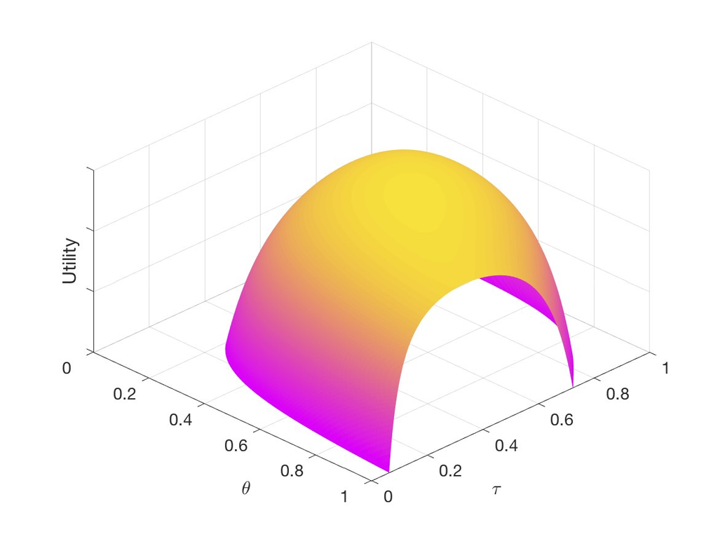

Figure 1: $U(\theta, \tau)$ with $l^i = 0.20$

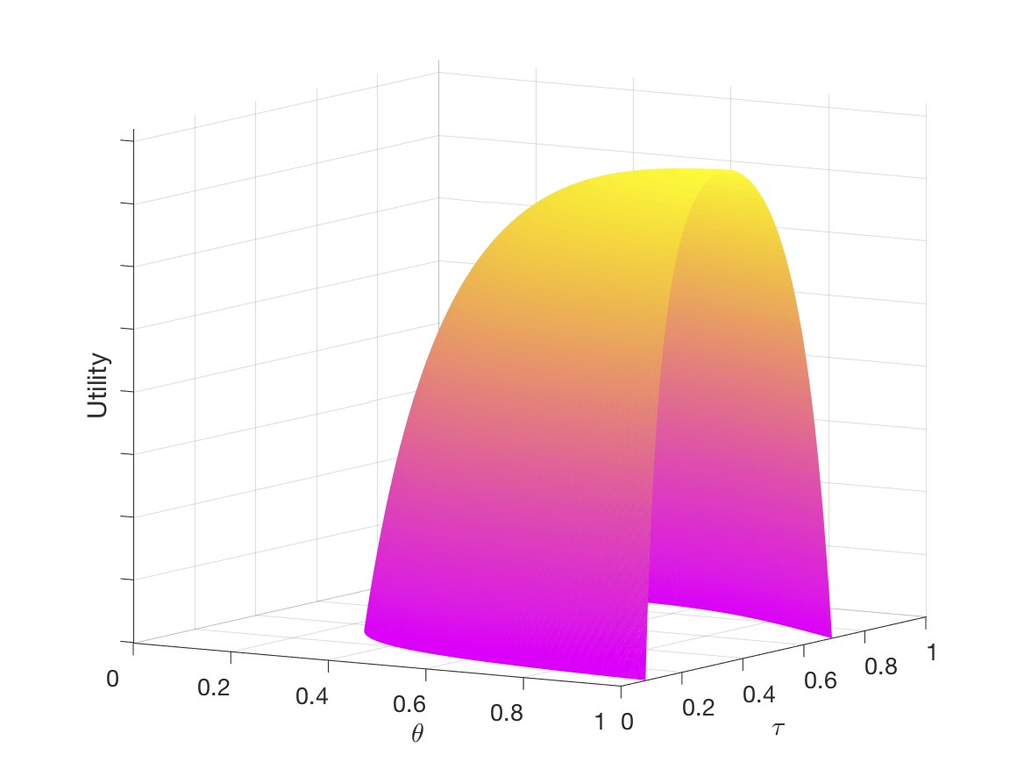

Figure 2: $U(\theta, \tau)$ with $l^i = 1$

Figure 3 shows the indifference curves for various agents who are poorer than the mean agent.

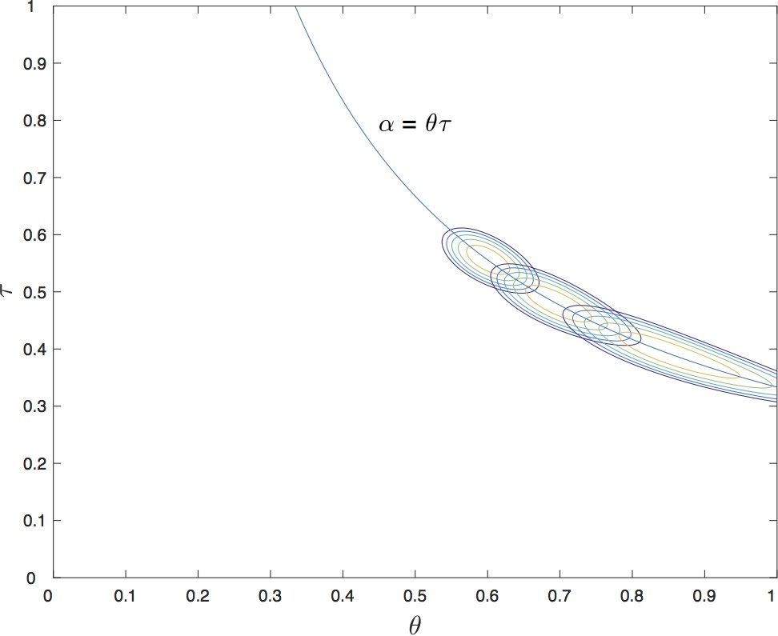

Figure 3: Isoutilities for Different Agents

## 2.4 Preferences over Policy

This section summarizes the agent $i$’s most preferred policy.

##### **Proposition 2:** $(i)$ With no transfers, the most preferred tax rate for any agent coincides with the growth maximizing tax rate. $(ii)$ With positive transfers, the most preferred tax rate for any agent exceeds $\tau = \alpha$.

**Proof**. Assume that policy is previously chosen to maximize growth. i.e. $\frac{\partial \gamma}{\partial \tau} =0$ holds. Differentiate $U^i(\cdot)$ with respect to $\tau$.

$\frac{\partial U^i}{\partial \tau} = \frac{(c_0^i)^{-\sigma}k_0 }{(1-\alpha) [\rho - \gamma(1-\sigma)]} \left\{ \frac{(\gamma \sigma + \rho) (1-\theta)}{(1-\tau)^2} \right\} +\frac{\partial U}{\partial \gamma} \frac{\partial \gamma}{\partial \tau}.$ $\quad(17)\quad$

Which is zero for $\theta =1$ (i.e. no transfers). And positive for all $\theta \in (0,1)$. $\Box$

So in an economy in which transfers are zero, i.e. $\theta = 1$, everyone’s optimum share of public capital to output, despite differences in their earnings abilities, is equal to $\alpha$, recall that according to proposition 1 this policy also maximizes growth. This result is exactly the same as that from Barro (1990), but it extends to the economy with heterogenous agents. In contrast, this result differs with Alesina and Rodrik (1994), there, as long as the agent receives any amount of labor income, his most preferred tax rate exceeds the growth maximizing rate, thus suboptimal in terms of growth. A key difference between the latter model and the one here is the tax base, there only the capital stock is taxed.

The second part of proposition 2 considers the case when $\theta \in (0,1)$. i.e. when transfers are positive. If this is the case, the amount of revenue collected by setting $\tau = \alpha$ is too little for any agent’s standards. That is, if some tax revenue will be used on transfers, tax policy should make up for it in a way that public capital is not ``excessively" compromised. With transfers, the most preferred the tax rate for any agent is higher than $\alpha$.

Differentiating $U^i(\cdot)$ with respect to $\theta$, we get the following expression.

$\frac{\partial U^i}{\partial \theta} = \frac{(c_0^i)^{-\sigma}k_0 }{(1-\alpha) [\rho - \gamma(1-\sigma)]} \left\{ - \frac{(\gamma \sigma + \rho)\tau }{1-\tau} \right\} +\frac{\partial U}{\partial \gamma} \frac{\partial \gamma}{\partial \theta}.$ $\quad(18)\quad$

The first part of the rhs of (18) is always negative and the second is always positive, somewhat reflecting the mechanics regarding the effects of a change on $\theta$. By increasing $\theta$, there’s always a positive effect by means of the effect on growth. The negative effect comes from the fact that by increasing $\theta$, the transfer to the agent becomes smaller, thus reducing the agent’s income.

In the parameterized exercise, the concavity of $U(\theta)$ is obtained for the relevant ranges and all tested (plausible and not-so-plausible) parameters. For a set of (better-off) agents, the upper limit $\theta = 1$ with $\frac{\partial U^i}{\partial \theta} \geq 0$ is binding and therefore optimum. Whereas for other, **sufficiently** poor agents, an optimum $\theta < 1$ in which $\frac{\partial U^i}{\partial \theta} = 0$ applies. For all agents, their most preferred policy platform always involve a share of public investment to output $\theta \tau$ equal to $\alpha$. This gives way to the following.

##### **Proposition 3:** The most preferred policy platform $(\theta, \tau)$ for any agent $i$ involves a share of public investment to output equal to $\alpha$.

**Proof.** $(i)$ For the agents for which $\frac{\partial U^i}{\partial \theta} > 0$ at $\theta = 1$, we can apply the first part of proposition 2. The result yields $\theta \tau = \tau = \alpha$. $(ii)$ For those agents for which $\frac{\partial U^i}{\partial \theta} = 0$ applies within $\theta \in (0,1]$, we set $\frac{\partial U^i}{\partial \theta} = \frac{\partial U^i}{\partial \tau} = 0$. Substitute for $\frac{\partial{\gamma}}{ \partial{\tau}} = \frac{1}{\sigma} (\theta \tau)^{\frac{\alpha}{1-\alpha}} (\alpha - \tau) \tau^{-1}$ and $\frac{\partial{\gamma}}{ \partial{\theta}}= \frac{1}{\sigma} (\theta \tau)^{\frac{\alpha}{1-\alpha}} (1 - \tau)\alpha \theta^{-1}$. The result to this problem yields $\theta \tau = \alpha$. $\Box$

Although an agent’s most preferred policy may involve different values for $\tau$ and $\theta$, his most preferred share of public investment to output will always be equal to $\alpha$. We can think of this as if an agent $i$ choses the size of the transfer, then simultaneously adjusts the size of the tax so that at the end the optimality condition $\theta \tau = \alpha$ is still met.

# 3 Political Determination of $\tau$ and $\theta$

## 3.1 Reaction Functions

The previous section described an individual’s most preferred policy without regard to the strategic interaction between agents with diverse preferences. An immediate lesson is that, as inequality becomes more severe, the ranges of most preferred policies becomes larger. And, as we will see in this section, the range of possible equilibrium policy outcomes also expands. Although a political-economy equilibrium has not been determined to this point, increasing the range of most preferred policies is likely to complicate the political process, and lend room for possible inefficiencies.

The following describes how a political outcome may emerge when policy is not chosen by a single agent but, instead, is the result of the interaction between unequal, rational agents. Specifically, I describe all agents’ policy preferences when they take the political process and the preferences of others as given. Finally, I will pin-down the equilibrium policy outcome for the median-voter benchmark described below.

For the reminder of this section, I will refer to an agent’s ability to earn income as $\phi^i = [ l^i, \kappa^i]$. Although not necessary, a sufficient condition for the following analysis to apply, is that the distribution of $\phi$ is such that $\kappa^i \geq \kappa^j$ for all $l^i \geq l^j$. Even though the necessary condition is weaker, for simplicity I will only assume the sufficient condition just described, having in mind that the analysis applies to a broader set of distributions.

Suppose that $\theta^{e}$ is the $\theta$ that has been politically determined in the range of $\theta \in (0,1]$. Let agent $i$ consider all possible winning $\theta^{e} \in (0,1]$. The following problem determines agent $i$’s most preferred tax rate for each of the possible values of $\theta^{e}$. The resulting vector will be a reaction function $\tau(\theta^{e})$ for agent $i$.

##### **Problem P1a:** Agent $i$’s most preferred $\tau$ for a given $\theta^{e}$ is the $\tau \in (0,1]$ that maximizes equation (16) subject to (12), with $k_0$, $k^i_0$, and $l^i$ given, for a given $\theta^{e} \in (0,1]$.

The reaction functions $\tau(\theta^{e})$ for several type $i \in I$ agents are depicted in Figure 4. For each type $i$ agent, for each $\theta^{e}$ there is a unique $\tau$ that maximizes his utility[^4], these tax rates are also the locus for which $\text{MU}^i_{\tau} = 0$ for each agent $i$, for each $\theta$. From this result, the most preferred tax rate monotonically decreases with $\phi$ for any given $\theta^{e}$, and with $\theta$ for any given agent.

Similarly, suppose that $\tau^{e}$ is the $\tau$ that has been politically determined in the range $\tau \in (0,1]$ and let agent $i$ consider all possible winning $\tau^{e} \in (0,1]$. The following problem determines agent $i$’s most preferred $\theta$ for each of the possible values of $\tau^{e}$. The resulting vector will be the reaction function $\theta(\tau^{e})$ for agent $i$.

##### **Problem P1b:** Agent $i$’s most preferred $\theta$ for a given $\tau^{e}$ is the $\theta \in (0,1]$ that maximizes equation (16) subject to (12), with $k_0$, $k^i_0$, and $l^i$ given, for a given $\tau^{e}$.

Figure 5 depicts the reaction functions $\theta(\tau^{e})$ for several type $i \in I$ of agents, the parameters and the distribution are the same as those used for figure 3. The lines in $\theta \in (0,1)$ are also the locus for which $\text{MU}^i_{\theta} = 0$ for each type of agent for each tax rate. Apart from the cases where $\text{MU}^i_{\theta}(1) = 0$ (where the lines start to fall), $\text{MU}^i_{\theta}(1) > 0$ . From this result, the most preferred share $\theta$ is monotonically increasing with $\phi$ for any given $\tau^{e}$ and monotonically decreasing with the tax rate for any given $i$.

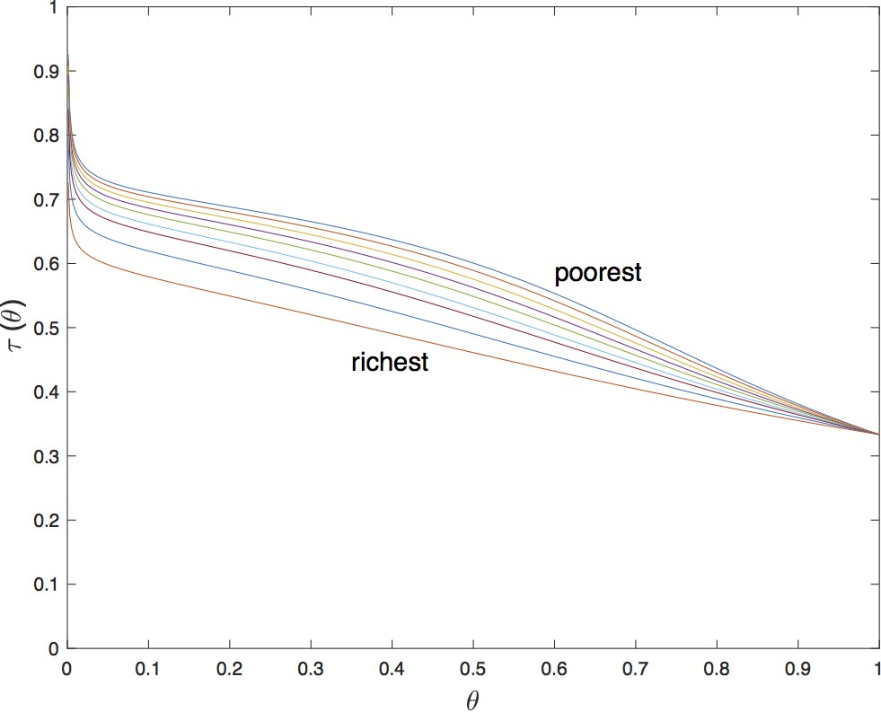

Figure 4: Most Preferred $\tau$ for $\theta \in (0,1]$

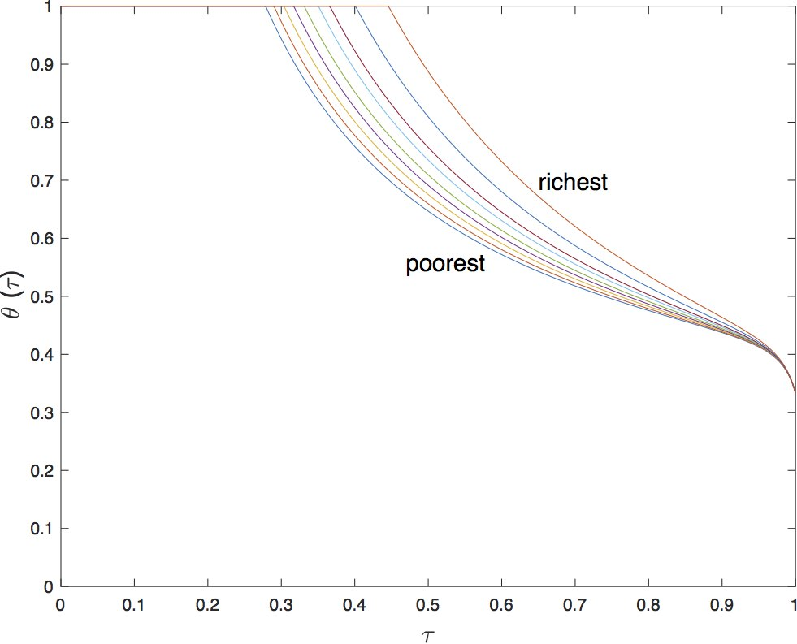

Figure 5: Most Preferred $\theta$ for $\tau \in (0,1]$

Figure 6 combines both reaction functions on the same plane. There, the intersection of the curves belonging to the same type of agent are the different agents’ bliss points (most preferred policy pairs), as they are described in proposition 3. At those points $\text{MU}^i_{\tau} = \text{MU}^i_{\theta} = 0$ or $\text{MU}^i_{\tau} = 0, \text{MU}^i_{\theta} > 0$, and $\theta(\tau^{e}) = 1$. Although at each intersection, the condition $\theta \tau =\alpha$ is maintained, an agent’s ideal $\theta$ is monotonically increasing with $\phi$, while his ideal tax rate is monotonically decreasing with $\phi$.

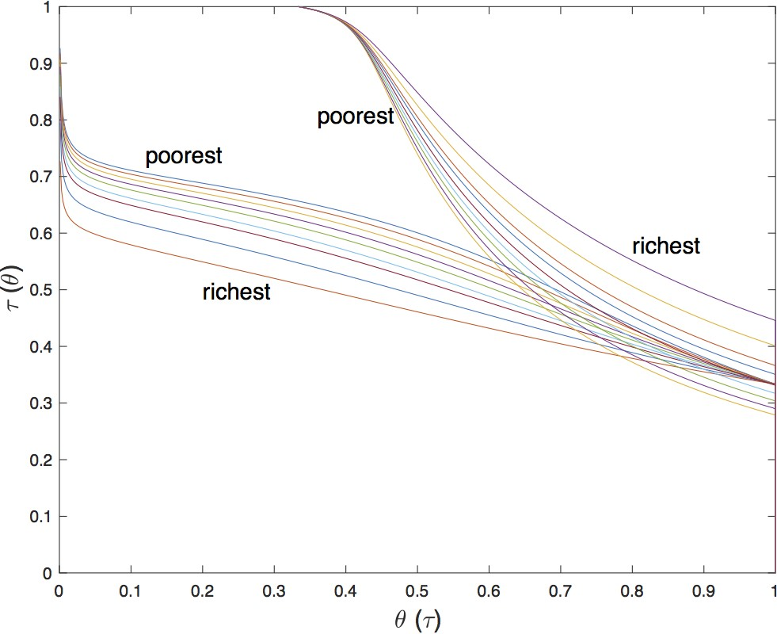

Figure 6: Reaction Functions Combined

## 3.2 Median Voter Equilibrium

The median voter theorem, in which the policy selected by the government is the one preferred by the median voter, provides a useful benchmark. Although this procedure should not be taken as a literal description of an actual political process, the purpose of using it as a benchmark is to capture the basic idea that a government is likely to be responsive to the wishes of the majority when distributional issues are at stake. The Condorcet candidate is the criterion that will be considered here for a political equilibrium. A Condorcet winner is the candidate that is preferred by a majority of voters in any two-candidate election against each of the other candidates.

The numerical exercise above established monotonic relationships between factor endowments and policy preferences on both of the policy issues. Such relationships, and the convexity and single peakedness of the the utility function (16) over the policy plane, guarantees the existence and uniqueness of a majority voting equilibrium when voting over $\tau$ for any given $\theta$ (resp. over $\theta$ for any given $\tau$). i.e., a value of $\tau$ such that there is no $\tau' \not= \tau$ that is favored by more than one half of the voters to $\tau$ (and similarly for $\theta$) in any two candidate elections. This equilibrium corresponds to the one-dimensional Condorcet winner.

Figure 7 shows the results of two candidate elections in which one candidate is the tax rate most preferred by the median agent for any given $\theta$, $\tau(\theta^{e}, \phi_{med})$, and the rival candidates are alternative values of $\theta$. The vertical axis counts the votes obtained by the rival candidate. Here, the number of voters is 29. The closest rivals to $\tau(\theta^{e}, \phi_{med})$ are those in its vicinity but no candidate is able to obtain the 15 votes necessary to defeat it. Figure 8 shows the same for $\theta(\tau^{e}, \phi_{med})$.

The above implies that if a majority equilibrium $(\theta^*, \tau^*)$ under simultaneous voting over the two issues exists, it must the unique ideal point of the median type of voter.

$\theta^* = \theta(\tau^*, \phi_{med}) \quad \text{and} \quad \tau^* = \tau(\theta^*, \phi_{med})$ $\quad(19)\quad$

The concavity of $U(\theta, \tau^*)$ and $U(\theta^*, \tau)$, as well as the results from proposition 3, imply that $(\theta^*, \tau^*)$ exists and is the unique optimum policy of the median type of voter. Thus $(\theta^*, \tau^*)$ is the unique Kramer-Shepsle[^5] type equilibrium in this model. Also, since

$\sum_{\{i \in I: U(\tau, \phi_i) - U (\tau^*, \phi_i)>0\}} \mu_i \leq \frac{1}{2} \quad \forall \tau \in (0,1],\\ \qquad \text{and} \quad \theta^* = \theta(\tau^*, \phi_{med})$ $\quad(20)\quad$

and analogous with respect to the other policy variable, $(\theta^*, \tau^*)$ is also the unique Stackelberg[^6] equilibrium in this model.

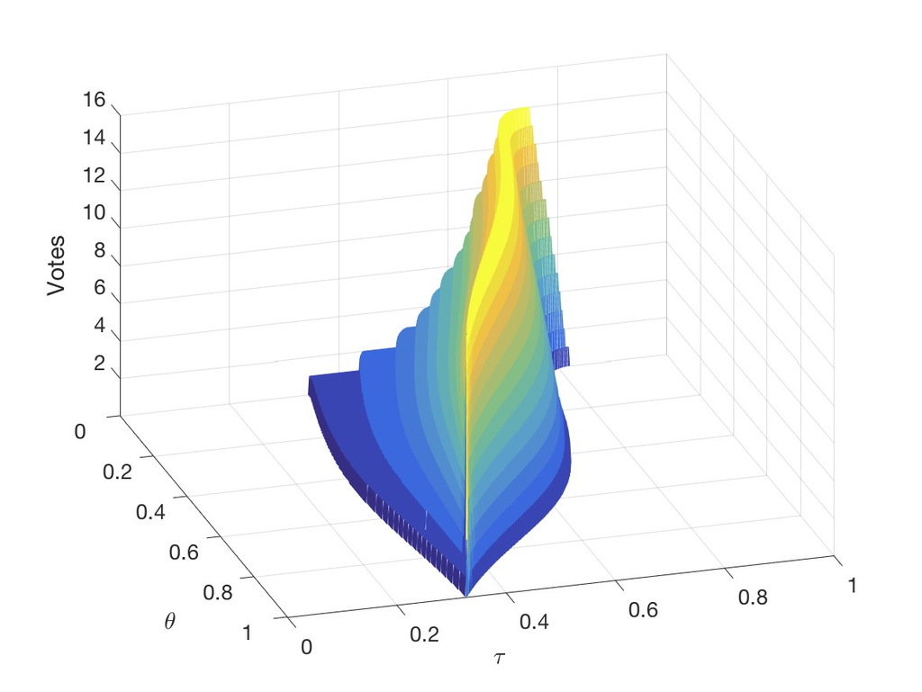

Figure 7: $\tau^{med}$ rivals’ votes

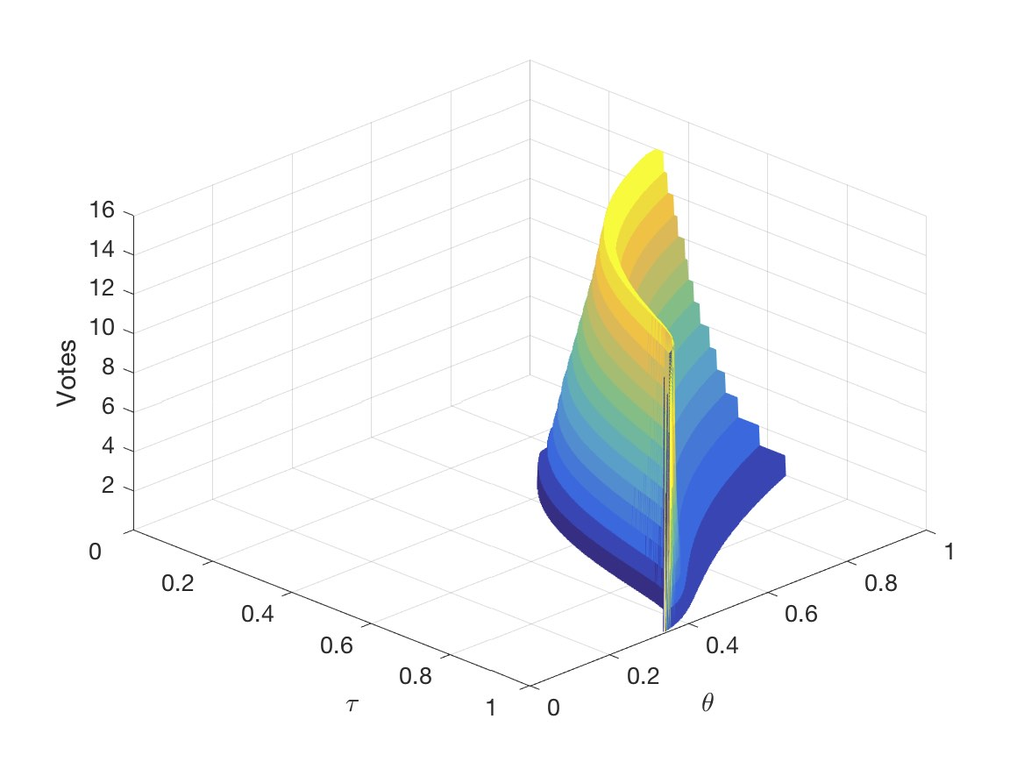

Figure 8: $\theta^{med}$ rivals’ votes

As a side note, despite of the political process, we can still discard the vast majority of policy pairs as politically implausible. Figure 9 depicts the set of Pareto Optimum platforms. There is no reason for a policy not in this set to be a political equilibrium. Additionally, the welfare maximizing policy also lies here. The numerical experiment indicates that the set of Pareto optimum policies is a thin `line’, around the $\tau \theta = \alpha$ line, where all agents’ most preferred policy pairs lie. Since the boundaries of this set appear to be determined by the agents with the lowest and highest $\phi$, the policy ranges in the Pareto Optimum set increases as the distribution of $\phi$ spreads out.

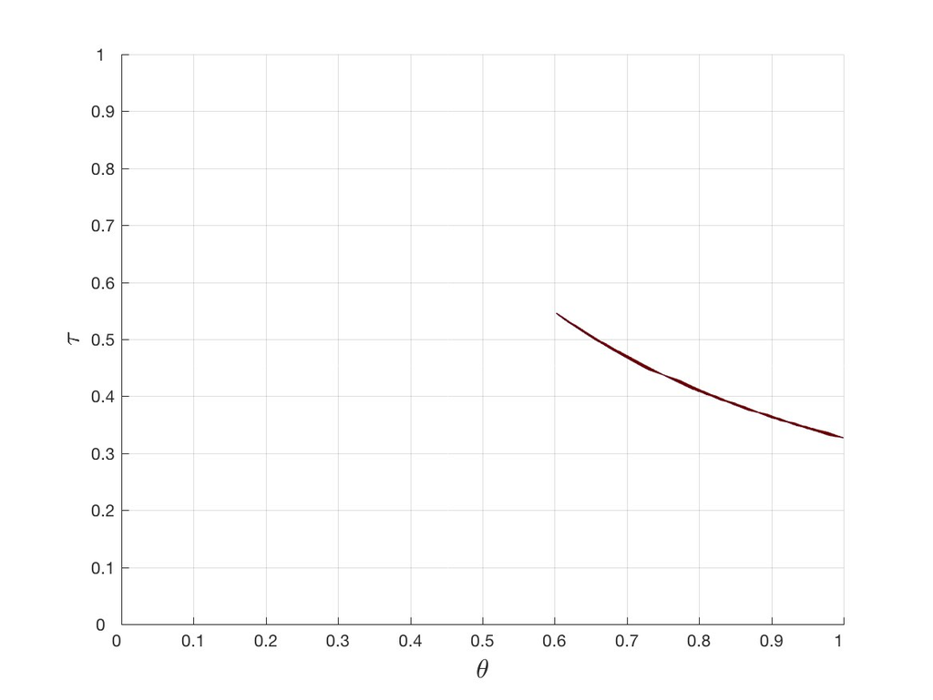

Figure 9: Pareto Optimum Policies

##### **Definition 1:** The unique Kramer-Shapsle and Stackelberg equilibrium $(\theta^*, \tau^*)$ in (19) is also the unique two-dimensional Condorcet winner if

$\sum_{\{i \in I: U(\theta, \tau, \phi_i) - U (\theta^*, \tau^*, \phi_i)>0\}} \mu_i \leq \frac{1}{2} \qquad \forall (\theta,\tau)\,\,\,\, in\,\,\,\, the\,\,\,\,plane\,\,\,\, \theta \in (0,1] \times \tau \in (0,1]$ $\quad(21)\quad$

That is, there does not exist an alternative candidate, that in a two-candidate election, can defeat $(\theta^*, \tau^*)$, i.e. attain over $50\%$ of the votes.

Figure 10 shows how rival candidates would fare against $(\theta^*, \tau^*)$ in two-candidate elections. For this illustration, without loss of generality, the number of voters is 29[^7]. The vertical axis represent the votes the median’s rivals attain. The platforms along the locus of bliss points (i.e. the $\tau \theta = \alpha$ line), and closer to the median, are the median’s platform closest rivals. However, none of them is able to obtain the required majority of 15 to defeat $(\theta^*, \tau^*)$. Thus, according to Definition 1, the platform most preferred by the median voter is the Condorcet winner[^8].

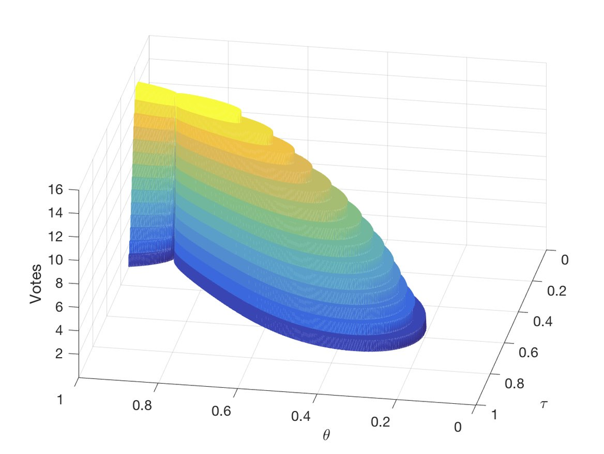

Figure 10: Votes for the Median Platform’s Rivals

If such is the case, and a median voter theorem does apply, we are able to pin down the political equilibrium policy simply by solving Problem P1 for the agent who is the median in the distribution of income. One implication is, that the optimality condition for the share of output spent on public capital is still met, i.e. $\theta \tau = \alpha$. So, as long as the policy elected is the most preferred by any one single agent, this will be the case. The political equilibrium for the example above yields an equilibrium policy $\tau = 0.36$ and $\theta = 0.91$, which implies that 1/3 of output would be devoted to public capital $g$, that is $g = \theta \tau y = \alpha y = \frac{1}{3}y$ and about $9$ percent of tax revenue to transfers $z$. Different pivotal agents however, will choose different combinations $(\tau, \theta)$. This is best described in figure 11. There, as the pivotal agent gets poorer, with respect to the mean agent, he will prefer a higher $\tau$ and a lower $\theta$. That is, he will extract more income from the rich agents by way of transfers.

The negative implication of the above in terms of growth, is that a higher tax rate implies more distortions. Nevertheless, the pivotal voter will try to minimize the distortion by choosing a policy combination such that $g = \alpha y$ (as seen by the dotted line in Figure 11). The higher equilibrium tax rate implies a lower growth rate along the BGP. This implication is depicted in figure 12. Here, as the pivotal voter gets poorer, he choses a higher tax rate, and thus creates distortions that slow-down economic growth. These distortions are what, a pivotal voter who is not sufficiently poor, will try to avoid.

When the pivotal voter is only slightly poorer than the mean agent, he will not readily benefit from a transfer. The distortions he would create by a higher tax rate, and a lower $\theta$, will not only reduce his private (non-transfer) income, but will also reduce the size of the pie from where he will be extracting the transfer. Thus he needs to be sufficiently poorer than the mean agent to rip personal benefits from a transfer. The dollar amount of the transfer would need to be larger than his combined loses from the two negative effects, this is what is mean by *sufficiently* poorer. Another reason for this, I suspect, is because the optimal tax rate from which he will be departing is already positive.

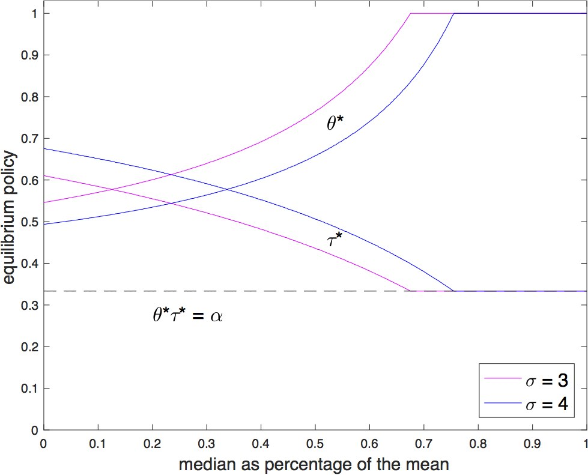

Figure 11: Equlibrium Policy vs. Skewness

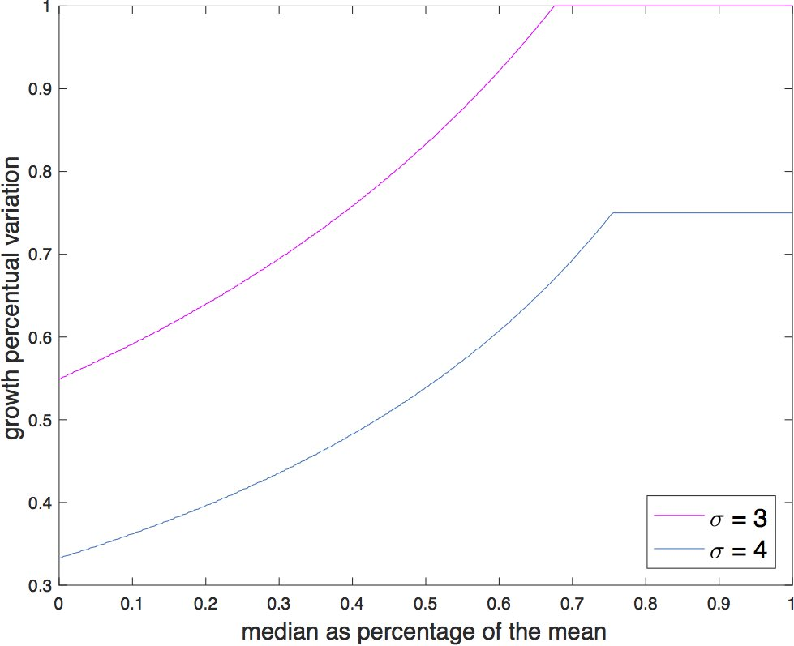

Figure 12: Growth Rate vs. Skewness

The qualitatively results described in this section are robust to variations on the parameters required for the numerical computations. Most of the effects of different distributions (which are the subject of this paper) are described in figures 11 and 12, and different distributions seem to affect equilibrium public policy. The sensitivity of the results to $\sigma$, although they are on the right direction, seem to be on an order of magnitude higher than could be satisfactorily explained. It appears that the output elasticity of public capital is an essential factor at predicting how much of total output should be spent on it and how economic agents act in regards to public policy, even in the heterogenous agents framework. The empirical literature offers a wide range of estimates ranging from 0.03 (Hulten and Schwab 1991), to 0.20 (Ai and Cassou 1993, And Lynde and Richmond 1993), to 0.39 and 0.56 (Aschauer 1989), so the value $\alpha = 1/3$ might overstate the value of $\theta \tau$ and the tax rate in the parameterization.

Other issues that might be considered are some of the simplifications of the model. Issues that the model abstracts from, and that might impact the results, are the value of leisure, social mobility, uncertainty about the state of the economy and employment. Other issues that were left out are congestion of public services and accumulation of public capital. Judging from existing literature, the former would have little impact on the results (Glomm and Ravikumar 1994). The exclusion of accumulable public capital likely overestimated the value of $\theta \tau$, mainly by means of an overestimated tax rate (see Dioikitopoulos 2008), but the qualitatively results should remain in line.

It would be interesting to address any of the issues mentioned above in further research, including a model which addresses time consistency and the impacts of policy reform. A likely extension would be to study the effects of equilibrium policies on welfare in a similar framework. This study address only issues regarding growth. However, the study of public policy determination and its effects on growth seem to be a step forward on making the connection between the choice of public policy and its effects on long-run welfare.

# 4 Conclusion

This paper presented a model of endogenous growth with heterogeneous agents in which redistribution and public investment policy compete for scarce tax revenue. It considered three issues in public policy, namely the size of the government, the share of government revenue devoted to transfers, and the share of government revenue spent on public infrastructure. And extended to see how the political determination of public policy affects growth.

It offered analytical solutions for the political preferences of heterogeneous agents, showing that all agents will always chose a policy combination that meets the optimality condition $\theta\tau = \alpha$. That is, a level of public investment that equals the output elasticity of public capital. Such result is consistent with previous literature in a representative agent context, but extends here to a heterogeneous agents framework.

Additionally, it found that some (better-off) agents prefer the growth maximizing public policy which consists of zero transfers. Whereas sufficiently poor agents, while still meeting the optimality condition, would chose a policy with positive transfers that have negative effects on growth.

For the political determination of policy, this paper provided numerical evidence that a median voter theorem applies. By appealing to such theorem, the relationship between heterogeneity and growth is addressed. According to this evidence, the political equilibrium policy can be pinned-down by knowing the income earning abilities of the agent who is the median in the distribution of income. If such median voter is sufficiently poorer than the mean, the political equilibrium will have negative effects on growth. This negative effect increases as inequality becomes more severe.

# Appendix

### A.1 Equality of the growth rates of individual and aggregate consumption

Without loss of generality, use $c=c^i+c^j$. Then, the growth rate of aggregate consumption,

$\frac{\dot{c}}{c} = \frac{\dot{c^i}}{c^j} \frac{{c^i}}{c} + \frac{\dot{c^j}}{c^j} \frac{{c^j}}{c} = [(1-\tau)r(\theta, \tau) - \rho ] \left( \frac{{c^i}}{c} + \frac{{c^j}}{c}\right) = \frac{\dot{c^i}}{c^i}$

### A.2 Equality of the growth rates of private and public capital

At the BGP we must have $d\gamma_c/dt = 0$, using $r$ in terms of productive inputs,

$\frac{d \gamma_c}{dt} = (1-\tau)(-\alpha) (1-\alpha) k^{-\alpha} g^{\alpha} \frac{\dot{k}}{k} - (1-\tau)(-\alpha) (1-\alpha) k^{-\alpha} g^{\alpha} \frac{\dot{g}}{g} = 0\\ \qquad\qquad\Rightarrow \frac{\dot{k}}{k} = \frac{\dot{g}}{g}$

### A.3 Equality of the growth rates of aggregate capital and aggregate consumption

Using the economy-wide budget constraint

$y = c + \dot{k} + g\\ \frac{\dot{k}}{k} = \frac{y}{k} - \frac{c}{k} - \frac{g}{k}$

Taking the time derivative and setting it equal to zero,

$\frac{d \gamma_k}{dt} = (-\alpha) k^{-\alpha} g^{\alpha} \frac{\dot{k}}{k} - (-\alpha) k^{-\alpha} g^{\alpha} \frac{\dot{g}}{g} - \frac{c}{k} \left[ \frac{ \dot{c}}{c} - \frac{\dot{k}}{k} \right] - \frac{g}{k} \left[ \frac{ \dot{g}}{g} - \frac{\dot{k}}{k} \right] = 0\\ \qquad\qquad \Rightarrow \frac{\dot{c}}{c} = \frac{\dot{k}}{k}.$

### A.4 Equality of the growth rates of individual assets and aggregate private capital

If policy $(\tau, \theta)$ is constant, we also have that $z$ grows at the same rate as above (see government’s budget constraint). And so do wages (see equation 3).

Dividing both sides of the individual budget constraint for agent $i$ by $k^i$, then taking the time derivative and setting it equal to zero,

$\frac{\dot{k^i}}{k^i} = (1-\tau)l^i w \frac{k}{k^i} + (1-\tau)r\frac{k^i}{k^i} + \frac{z}{k^i} - \frac{c^i}{k^i}$

$\frac{d(\dot{k^i}/k^i)}{dt} = (1-\tau)l^i w \left[ \frac{\dot{k}}{k^i} - k\frac{\dot{k^i}}{k^{i^2}} \right] + 0 + \frac{\dot{z}}{k^i} - z\frac{\dot{k^i}}{k^{i^2}} + c^i\frac{\dot{k^i}}{k^{i^2}} - \frac{\dot{c^i}}{k^i} =0$

$\qquad\qquad = (1-\tau)l^i w \frac{k}{k^i} \left[ \frac{\dot{k}}{k} - \frac{\dot{k^i}}{k^{i}} \right] + \frac{z}{k^i} \left[ \frac{\dot{z}}{z} - \frac{\dot{k^i}}{k^{i}} \right] +\frac{c^i}{k^i} \left[ \frac{\dot{k^i}}{k^{i}} - \frac{\dot{c^i}}{c^i} \right] =0$

substituting the growth rates of $z$ and $c$ for $\dot{k}/{k}$ we have that the above implies

$\frac{\dot{k}}{k} = \frac{\dot{k^i}}{k^{i}}$

Thus, we have

$\frac{\dot{c^i}}{c^i} = \frac{\dot{c}}{c} = \frac{\dot{k}}{k} = \frac{\dot{g}}{g} = \frac{\dot{z}}{z} =\frac{\dot{k^i}}{k^{i}} \equiv \gamma$

is the growth rate of all individual and aggregate variables along the BGP.

# References

1. Alesina, Alberto, and Dani Rodrik (1994). Distributive Politics and Economic Growth. *The Quarterly Journal of Economics*, May.
2. Alesina, Alberto, and Perotti, R. (1995). Income Distribution, Political Instability and Investment. Discussion Papers 1995 22, Columbia University, Department of Economics.
3. Aschauer, David A. (1989). Is Public Expenditure Productive? *Journal of Monetary Economics*.
4. Azzimonti-Renzo, Marina, Pierre-Daniel G. Sarte and Jorge Soares, (2003). Optimal Public Investment with and without Government Commitment. Federal Reserve Bank of Richmond, Working Paper 03-10.
5. Barro, Robert J. (1990). Government Spending in a Simple Model of Endogenous Growth. *Journal of Political Economy*, October.
6. Barro, Robert J., and Xavier Sala-I-Martin (1992). Public Finance in Models of Economic Growth. *Review of Economic Studies*, October.
7. Bertola, Giuseppe (1993). Factor Shares, Saving Propensities, and Endogenous Growth, *American Economic Review*, December.
8. De Donder, Philippe, Michel Le Breton, and Eugenio Peluso (2010). Majority Voting in Multidimensional Policy Spaces: Kramer-Shepsle Versus Stackelberg. CEPR Discussion Paper No. DP7646. January
9. Fisher, Walter and Stephen J. Turnovsky (1998). Public Investment, Congestion, and Private Capital Accumulation. *The Economic Journal*, March.
10. Galor, Oded and Zeira, Joseph, (1993). Income Distribution and Macroeconomics. *Review of Economic Studies*.
11. Glomm, Gerhard, and B. Ravikumar (1994). Public Investment In Infrastructure In A Simple Growth Model. *Journal of Economic Dynamics and Control*.
12. ________________ (1997). Productive Government Expenditures And Long-Run Growth. *Journal of Economic Dynamics and Control*, October.
13. ________________ (1999). Competitive Equilibrium and Public Investment Plans. *Journal of Economic Dynamics and Control*.
14. Guedes de Oliveira, Francisca (2007). Public Investment, Distributive Politics and Economic Growth. Universidade Catolica Portuguesa, Porto. Working Papers. No. 19
15. Imrohoroglu, Ayse, Antonio Merlo and Peter Rupert (1998). On the Political Economy of Income Redistribution and Crime.
16. Jones, Larry E., Rodolfo E. Manuelli and Peter E. Rossi (1993). Optimal Taxation in Models of Endogenous Growth. *Journal of Economic Theory*.
17. King, Robert G., and Sergio Rebelo (1990). Public Policy and Economic Growth: Developing Neoclassical Implications. *The Journal of Political Economy*, October.
18. Krusell, Per, and Jose-Victor Rios-Rull (1999). On the Size of U.S. Government: Political Economy in the Neoclassical Growth Model. *The American Economic Review*, December.
19. Kuznets, Simon (1955). Economic Growth and Inequality. *The American Economic Review*, March.
20. Lucas, Robert Jr., (1988). On the Mechanics of Economic Development. *Journal of Monetary Economics*, July.
21. Mayer, Wolfgang, (1984). Endogenous Tariff Formation. *American Economic Review*, December.
22. Meltzer, Allan, and Scott F. Richard (1981). A Rational Theory of the Size of Government, *Journal of Political Economy*, October.
23. Persson, Torsten, and Guido Tabellini (1991). Is Inequality Harmful for Growth? Theory and Evidence, NBER Working Papers 3599.
24. Romer, Paul M, (1986). Increasing Returns and Long-run Growth, *Journal of Political Economy*, October.
25. Shepsle, K. A. (1979). Institutional Arrangements and Equilibrium in Multidimensional Voting Models. *American Journal of Political Science*, 23
26. Turnovsky, Stephen J. (1997). Fiscal Policy in a Growing Economy with Pubic Capital. *Macroeconomic Dynamics*.
27. Zak, Paul J and Knack, Stephen, (2001). Trust and Growth. *Economic Journals*, April

#### Footnotes

[^1]: This version: October 2012. First version: March 2010.
[^2]: Turnovsky (1998), Jones Manuelli and Rossi (1993), Glomm and Ravikumar (1994, 1997, 1999) are among the many other theoretical papers that study a productive role for the government.
[^3]: cf. footnote 4 for parameter values
[^4]: The parameters used for this excercise, are $\alpha = 1/3$, $\rho = 0.02$, $\sigma = 3$, and heterogeneity only on productivity. The parameter $\alpha=1/3$ was chosen to roughly be between that originally estimated by Aschauer (1989), 0.39 and the one used by Barro (1990) 0.25. $\rho=0.02$ was borrowed from Barro (1990). $\sigma = 3$ was chosen, among plausible values, for aesthetical reasons, alternative values of 2 and 4 do not affect the conclusions. The distribution was chosen to match the mean U.S. household income being about 36% higher than the median, and fitting a log-normal distribution with associated $\mathcal{N}(1,1.4)$.
[^5]: For a detailed definition see De Donder et al 2010.
[^6]: ibid.
[^7]: The parameters and the distribution are the same used in the previous examples, for this figure the number of types of agents is $I=29$ of equal mass, so the simple majority is given by 15 votes.
[^8]: This result holds for any median platform tested. While competing against $(\theta^*, \tau^*)$, the maximum number of votes any other candidate attains is 14 votes.